# New York School Outcomes and County Poverty

2016 county and school comparisons

## Questions and approach

This report asks how access to free or reduced-price lunch relates to school test performance, and how average test performance differs among counties with low, medium, and high poverty. It also summarizes enrollment and lunch eligibility by county and compares counties with the highest and lowest poverty rates.

The analysis uses 2016, the latest year shared by the school and county poverty data. School test scores are expressed as within-year z-scores because the test scale changes across years. A z-score of zero is the 2016 school average. These comparisons describe associations, not causes.

## County summary

The lunch percentage is weighted by school enrollment. The county poverty rate is taken once per county, since it repeats on every school row. Raw test scores below are enrollment-weighted school averages within 2016.

```r
county_summary = school_data |>
  filter(year == 2016, !is.na(county_name), !is.na(county_per_poverty)) |>
  mutate(per_free_or_reduced = per_free_lunch + per_reduced_lunch) |>
  group_by(county_name) |>
  summarize(
    total_enrollment = sum(total_enroll, na.rm = TRUE),
    pct_free_or_reduced = 100 * weighted_avg(
      per_free_or_reduced, total_enroll
    ),
    pct_poverty = 100 * first(county_per_poverty),
    mean_reading_score = weighted_avg(mean_ela_score, total_enroll),
    mean_math_score = weighted_avg(mean_math_score, total_enroll)
  )

county_summary |>
  select(county_name, total_enrollment, pct_free_or_reduced, pct_poverty) |>
  arrange(desc(pct_poverty))
```

```
## # A tibble: 62 × 4
##    county_name    total_enrollment pct_free_or_reduced pct_poverty
##    <chr>                     <dbl>               <dbl>       <dbl>
##  1 BRONX                    178274                84.2        29.8
##  2 KINGS                    249479                72.0        22.5
##  3 MONTGOMERY                 4903                57.2        20.2
##  4 CHAUTAUQUA                13445                57.1        18.5
##  5 OSWEGO                    13082                56.9        17.5
##  6 TOMPKINS                   7916                43.6        17.4
##  7 SAINT LAWRENCE            11368                55.6        17.1
##  8 NEW YORK                 115541                65.0        17.1
##  9 FRANKLIN                   5177                59.0        17.1
## 10 CATTARAUGUS                9051                54.4        16.9
## # ℹ 52 more rows
```

**Takeaway:** The table shows substantial differences in enrollment and poverty across counties. The lunch percentage describes students in the schools in this dataset, and the poverty percentage describes the county population.

### Counties at the poverty extremes

```r
top_bottom_poverty = bind_rows(
  county_summary |>
    slice_max(pct_poverty, n = 5) |>
    mutate(group = "Top 5"),
  county_summary |>
    slice_min(pct_poverty, n = 5) |>
    mutate(group = "Bottom 5")
  ) |>
  select(group, county_name, pct_poverty, pct_free_or_reduced,
         mean_reading_score, mean_math_score)

top_bottom_poverty
```

```
## # A tibble: 10 × 6
##    group    county_name pct_poverty pct_free_or_reduced mean_reading_score
##    <chr>    <chr>             <dbl>               <dbl>              <dbl>
##  1 Top 5    BRONX             29.8                 84.2               296.
##  2 Top 5    KINGS             22.5                 72.0               307.
##  3 Top 5    MONTGOMERY        20.2                 57.2               288.
##  4 Top 5    CHAUTAUQUA        18.5                 57.1               297.
##  5 Top 5    OSWEGO            17.5                 56.9               294.
##  6 Bottom 5 PUTNAM             5.09                20.8               311.
##  7 Bottom 5 NASSAU             5.92                28.9               315.
##  8 Bottom 5 SARATOGA           6.31                24.0               313.
##  9 Bottom 5 SUFFOLK            7.11                38.5               305.
## 10 Bottom 5 DUTCHESS           8.64                32.9               302.
## # ℹ 1 more variable: mean_math_score <dbl>
```

**Takeaway:** This table makes the county comparison concrete: it places poverty, lunch eligibility, and both test subjects side by side. Raw scores are compared only within 2016; the z-scores below are better for interpreting relative performance.

## Question 1: Lunch eligibility and school test performance

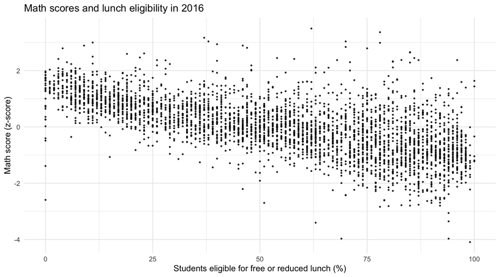

```r
data_2016 = school_data |>
  filter(year == 2016) |>
  mutate(lunch_pct = 100 * (per_free_lunch + per_reduced_lunch))

ggplot(data_2016) +
  geom_point(aes(x = lunch_pct, y = math_z),
             alpha = 0.8, cex = 0.5) +
  labs(
    title = "Math scores and lunch eligibility in 2016",
    x = "Students eligible for free or reduced lunch (%)",
    y = "Math score (z-score)"
  ) +
  theme_minimal()
```

## Question 2: Test performance by county poverty group

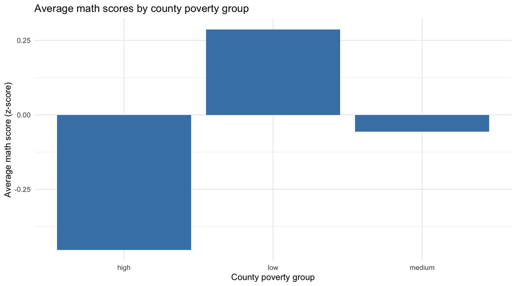

```r
group_scores = data_2016 |>
  group_by(county_name, poverty_group) |>
  summarize(math_z = mean(math_z, na.rm = TRUE)) |>
  group_by(poverty_group) |>
  summarize(math_z = mean(math_z, na.rm = TRUE))

ggplot(group_scores) +
  geom_col(aes(x = poverty_group, y = math_z),
           fill = "steelblue") +
  labs(
    title = "Average math scores by county poverty group",
    x = "County poverty group",
    y = "Average math score (z-score)"
  ) +
  theme_minimal()
```